# Exercise 4

Alicia Weber

13 February, 2025

# 1 Q4

```r
#file.choose()
dd <- read.delim("/Users/lish/Desktop/data_omics/squid1.txt")
head(dd)
```

```
##   sample.no specimen year month weight sex maturity.stage DML eviscerate.weight
## 1 105128901     1002 1989    12  152.0   2              3 174              87.5
## 2 105128901     1003 1989    12  105.9   2              1 153              62.6
## 3 105128901     1005 1989    12  138.4   2              2 169              79.4
## 4 105128901     1007 1989    12  140.8   2              2 175              83.1
## 5 105128901     1008 1989    12  126.2   2              3 169              72.2
## 6 105128901     1009 1989    12   54.3   2              1 116              30.2
##   dig.weight nid.length nid.weight ovary.weight
## 1      4.648       39.4      2.460        1.680
## 2      3.138       24.1      0.319        0.103
## 3      0.307       39.0      1.169        0.289
## 4      4.123       41.4      1.631        0.252
## 5      3.605       39.8      2.030        0.860
## 6      1.092       20.0      0.148        0.016
```

# 2 Q5

```r
#nr of observations
nrow(dd)
```

```
## [1] 519
```

```r
#nr of variables
ncol(dd)
```

```
## [1] 13
```

```r
#modify dd with factors
dd$year.f <- as.factor(dd$year)
dd$month.f <- as.factor(dd$month)
dd$maturity.stage.f <- as.factor(dd$maturity.stage)
str(dd)
```

```
## 'data.frame':    519 obs. of  16 variables:
##  $ sample.no        : int  105128901 105128901 105128901 105128901 105128901 105128901 105128901 105128901 105128901 105128901 ...
##  $ specimen         : int  1002 1003 1005 1007 1008 1009 1011 1013 1014 1017 ...
##  $ year             : int  1989 1989 1989 1989 1989 1989 1989 1989 1989 1989 ...
##  $ month            : int  12 12 12 12 12 12 12 12 12 12 ...
##  $ weight           : num  152 106 138 141 126 ...
##  $ sex              : int  2 2 2 2 2 2 2 2 2 2 ...
##  $ maturity.stage   : int  3 1 2 2 3 1 2 3 3 4 ...
##  $ DML              : int  174 153 169 175 169 116 135 192 170 205 ...
##  $ eviscerate.weight: num  87.5 62.6 79.4 83.1 72.2 ...
##  $ dig.weight       : num  4.648 3.138 0.307 4.123 3.605 ...
##  $ nid.length       : num  39.4 24.1 39 41.4 39.8 20 14 55 44 53 ...
##  $ nid.weight       : num  2.46 0.319 1.169 1.631 2.03 ...
##  $ ovary.weight     : num  1.68 0.103 0.289 0.252 0.86 ...
##  $ year.f           : Factor w/ 3 levels "1989","1990",..: 1 1 1 1 1 1 1 1 1 1 ...
##  $ month.f          : Factor w/ 12 levels "1","2","3","4",..: 12 12 12 12 12 12 12 12 12 12 ...
##  $ maturity.stage.f : Factor w/ 5 levels "1","2","3","4",..: 3 1 2 2 3 1 2 3 3 4 ...
```

# 3 Q9

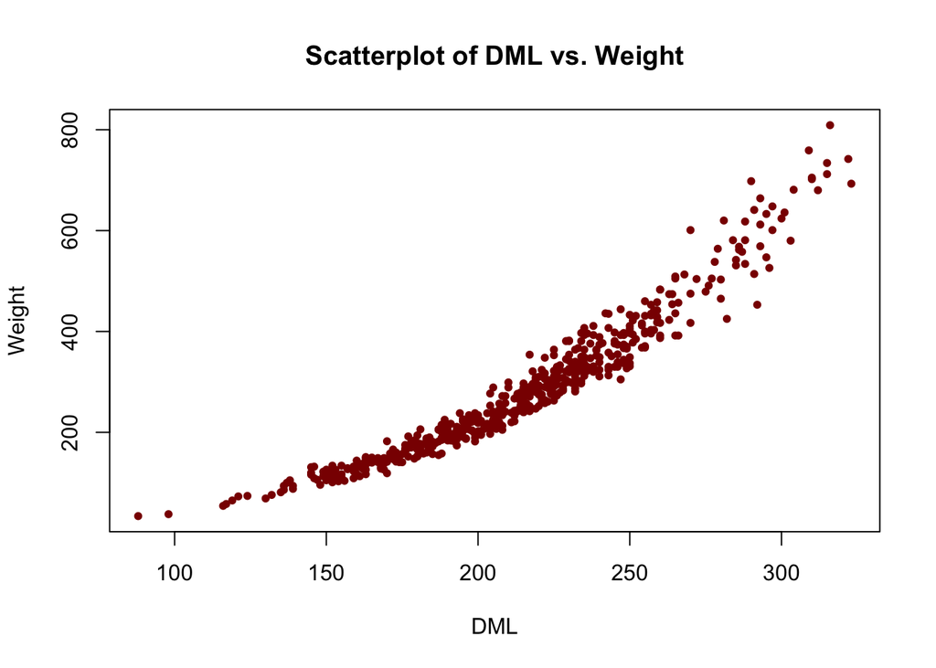

```r
#scatter plot shows rather exponential relationship
#pdf("DML_vs_Weight_alicia_weber.pdf", width = 6, height = 4)
plot(dd$DML, dd$weight,
     xlab = "DML",
     ylab = "Weight",
     main = "Scatterplot of DML vs. Weight", pch=20, col = "darkred")
```

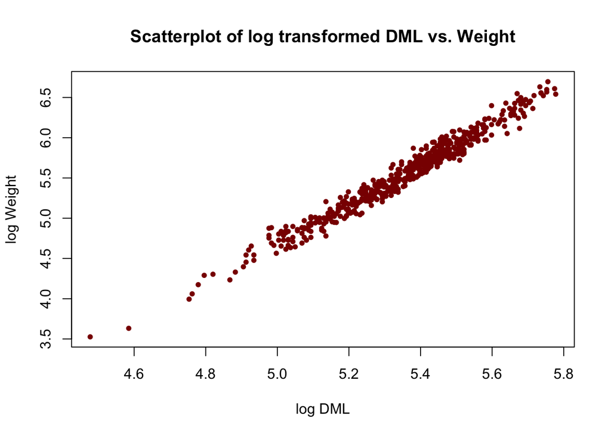

```r
#dev.off()

#transformation
dd$DML.log <- log(dd$DML)
dd$weight.log <- log(dd$weight)
dd$DML.sqrt <- sqrt(dd$DML)
dd$weight.sqrt <- sqrt(dd$weight)

#plot log transf
#pdf("DML_vs_Weight_log_alicia_weber.pdf", width = 6, height = 4)
plot(dd$DML.log, dd$weight.log,
     xlab = "log DML",
     ylab = "log Weight",
     main = "Scatterplot of log transformed DML vs. Weight", pch=20, col = "darkred")
```

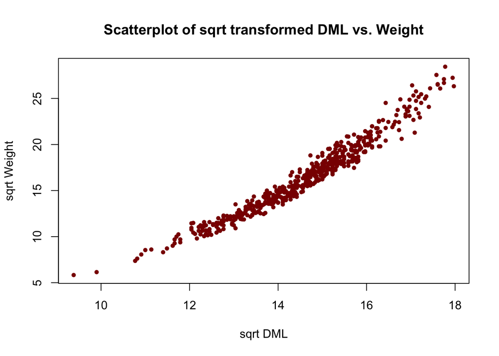

```r
#dev.off()

#plot sqrt transf
#pdf("DML_vs_Weight_sqrt_alicia_weber.pdf", width = 6, height = 4)
plot(dd$DML.sqrt, dd$weight.sqrt,
     xlab = "sqrt DML",
     ylab = "sqrt Weight",
     main = "Scatterplot of sqrt transformed DML vs. Weight", pch=20, col = "darkred")
```

```r
#dev.off()

#log transformation works best
```

# 4 Q10

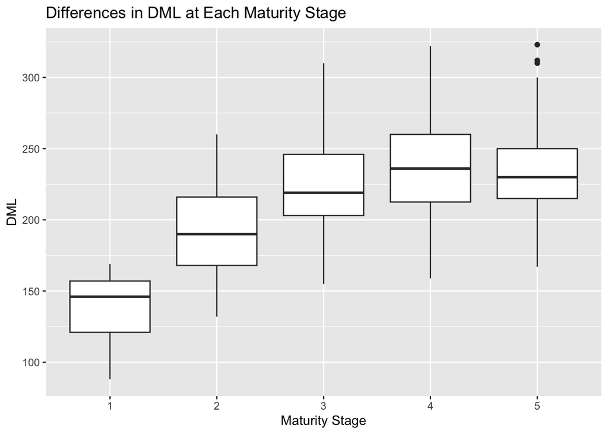

```r
#pdf("Boxplot_DML_Maturity_alicia_weber.pdf", width = 6, height = 4)
ggplot(dd, aes(x = factor(maturity.stage.f), y = DML)) +
  geom_boxplot() +
  labs(x = "Maturity Stage", y = "DML",
       title = "Differences in DML at Each Maturity Stage")
```

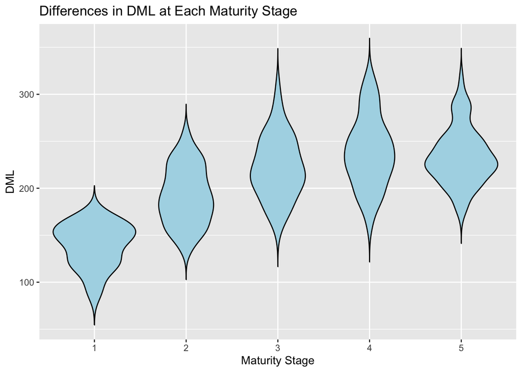

```r
#dev.off()

#pdf("Violinplot_DML_Maturity_alicia_weber.pdf", width = 6, height = 4)
ggplot(dd, aes(x = maturity.stage.f, y = DML)) +
  geom_violin(trim = FALSE, fill = "lightblue", color = "black") +
  labs(x = "Maturity Stage", y = "DML",
       title = "Differences in DML at Each Maturity Stage")
```

```r
#dev.off()
```

# 5 Q12, used ChatGPT help

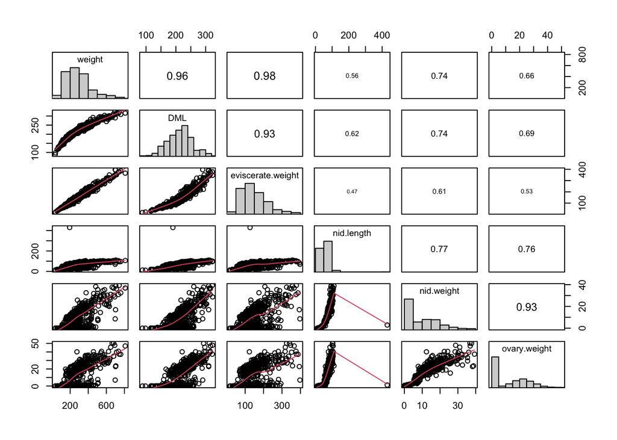

```r
# Histogram
panel.hist <- function(x, ...) {
  usr <- par("usr"); on.exit(par(usr))
  par(usr = c(usr[1:2], 0, 1.5))
  h <- hist(x, plot = FALSE)
  breaks <- h$breaks
  nB <- length(breaks)
  y <- h$counts / max(h$counts)
  rect(breaks[-nB], 0, breaks[-1], y, col = "lightgray", ...)
}

# Correlation
panel.cor <- function(x, y, digits = 2, prefix = "", cex.cor = 1.2, ...) {
  usr <- par("usr"); on.exit(par(usr))
  par(usr = c(0, 1, 0, 1))
  r <- cor(x, y, use = "complete.obs")
  txt <- formatC(r, format = "f", digits = digits)
  txt <- paste0(prefix, txt)
  text(0.5, 0.5, txt, cex = cex.cor * abs(r))
}

# pairs function
pairs(dd[, c(5, 8, 9, 11, 12, 13)],
      diag.panel = panel.hist,
      upper.panel = panel.cor,
      lower.panel = panel.smooth)
```

# 6 Session Information

**R version 4.4.1 (2024-06-14)**

**Platform:** aarch64-apple-darwin20

**locale:** en_US.UTF-8||en_US.UTF-8||en_US.UTF-8||C||en_US.UTF-8||en_US.UTF-8

**attached base packages:** *stats*, *graphics*, *grDevices*, *utils*, *datasets*, *methods* and *base*

**other attached packages:** *lubridate(v.1.9.3)*, *forcats(v.1.0.0)*, *stringr(v.1.5.1)*, *dplyr(v.1.1.4)*, *purrr(v.1.0.2)*, *tidyr(v.1.3.1)*, *tibble(v.3.2.1)*, *ggplot2(v.3.5.1)*, *tidyverse(v.2.0.0)* and *readr(v.2.1.5)*

**loaded via a namespace (and not attached):** *sass(v.0.4.9)*, *utf8(v.1.2.4)*, *generics(v.0.1.3)*, *stringi(v.1.8.4)*, *hms(v.1.1.3)*, *digest(v.0.6.37)*, *magrittr(v.2.0.3)*, *evaluate(v.1.0.1)*, *grid(v.4.4.1)*, *timechange(v.0.3.0)*, *bookdown(v.0.42)*, *fastmap(v.1.2.0)*, *jsonlite(v.1.8.9)*, *fansi(v.1.0.6)*, *pander(v.0.6.5)*, *scales(v.1.3.0)*, *jquerylib(v.0.1.4)*, *cli(v.3.6.3)*, *rlang(v.1.1.4)*, *munsell(v.0.5.1)*, *withr(v.3.0.2)*, *cachem(v.1.1.0)*, *yaml(v.2.3.10)*, *tools(v.4.4.1)*, *tzdb(v.0.4.0)*, *colorspace(v.2.1-1)*, *vctrs(v.0.6.5)*, *R6(v.2.5.1)*, *lifecycle(v.1.0.4)*, *pkgconfig(v.2.0.3)*, *pillar(v.1.9.0)*, *bslib(v.0.8.0)*, *gtable(v.0.3.6)*, *glue(v.1.8.0)*, *Rcpp(v.1.0.13)*, *xfun(v.0.48)*, *tidyselect(v.1.2.1)*, *highr(v.0.11)*, *rstudioapi(v.0.17.1)*, *knitr(v.1.48)*, *farver(v.2.1.2)*, *htmltools(v.0.5.8.1)*, *rmarkdown(v.2.28)*, *labeling(v.0.4.3)* and *compiler(v.4.4.1)*